# Projeto Métodos de Aprendizagem Não supervisionados - PCA na base de dados com Imputação

# Estandardizar os dados

```r
data_scaled <- scale(IrlandaImput)
data_scaled %>% glimpse()
```

```
##  num [1:5048, 1:41] 0.763 0.543 1.786 1.847 0.543 ...
##  - attr(*, "dimnames")=List of 2
##   ..$ : NULL
##   ..$ : chr [1:41] "PV1SCIE" "PV1READ" "PV1MATH" "SOCONPA" ...
##  - attr(*, "scaled:center")= Named num [1:41] 500.604 523.894 503.255 0.16 -0.198 ...
##   ..- attr(*, "names")= chr [1:41] "PV1SCIE" "PV1READ" "PV1MATH" "SOCONPA" ...
##  - attr(*, "scaled:scale")= Named num [1:41] 87.077 88.265 76.416 0.922 0.893 ...
##   ..- attr(*, "names")= chr [1:41] "PV1SCIE" "PV1READ" "PV1MATH" "SOCONPA" ...
```

```r
# Dúvida: Estandardizamos os dados de variáveis que não têm distribuição normal?
```

# PCA

Nesta parte, passaremos então para o processo de criação de PCA’s. Podemos então começar por pensar algumas ideias por alto, podendo ser estas:

- **PCA de Desempenho Acadêmico**:
  - Variáveis de interesse: Pontuações em diferentes domínios acadêmicos, como leitura, matemática e ciências.
  - Objetivo: Compreender a estrutura subjacente do desempenho acadêmico dos alunos e identificar padrões gerais de habilidades e competências.
- **PCA de Fatores Socioeconômicos**:
  - Variáveis de interesse: Variáveis socioeconômicas, como o nível de educação dos pais, ocupação dos pais, renda familiar, acesso a recursos educacionais, etc.
  - Objetivo: Explorar as relações entre os fatores socioeconômicos e o desempenho acadêmico dos alunos, bem como identificar grupos de alunos com perfis socioeconômicos semelhantes.
- **PCA de Atitudes e Comportamentos**:
  - Variáveis de interesse: Variáveis relacionadas a atitudes, motivação, autoeficácia, disciplina, participação em atividades extracurriculares, etc.
  - Objetivo: Identificar padrões de atitudes e comportamentos dos alunos que podem influenciar seu desempenho académico e bem-estar geral.
- **PCA de Ambiente Escolar**:
  - Variáveis de interesse: Variáveis relacionadas ao ambiente escolar, como tamanho da turma, recursos educacionais disponíveis, clima escolar, relacionamento professor-aluno, etc.
  - Objetivo: Explorar a relação entre o ambiente escolar e o desempenho dos alunos, bem como identificar características importantes do ambiente que afetam o aprendizado.

## Criação do PCA

```r
dim(data_scaled)
```

```
## [1] 5048   41
```

```r
pc1 <- principal(data_scaled, nfactors=10, rotate="none")
```

### Kaiser Criterion

```r
valores <- round(pc1$values,3)
valores
```

```
##  [1] 6.288 4.196 3.362 2.778 2.661 2.114 1.628 1.222 1.078 1.012 0.958 0.894
## [13] 0.740 0.687 0.669 0.641 0.624 0.603 0.571 0.564 0.547 0.534 0.522 0.515
## [25] 0.506 0.497 0.472 0.465 0.450 0.428 0.419 0.402 0.375 0.349 0.335 0.318
## [37] 0.185 0.161 0.120 0.084 0.027
```

```r
length(valores[valores > 1])
```

```
## [1] 10
```

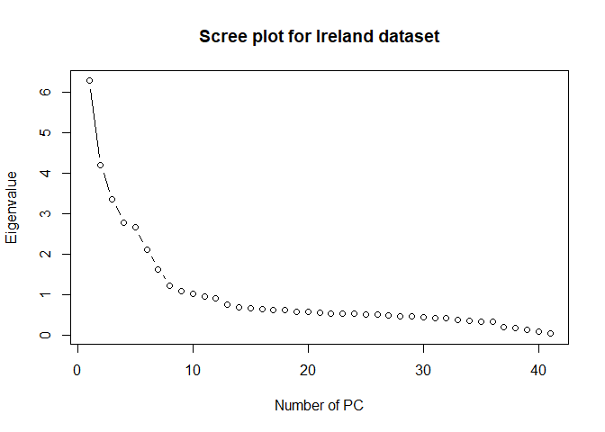

```r
plot(pc1$values, type = "b", main = "Scree plot for Ireland dataset",
     xlab = "Number of PC", ylab = "Eigenvalue")
```

Analisando o gráfico com atenção, é possível visualizar que existem várias quedas brutas, devido a isso, serão realizados vários testes com diferentes valores.

## PCA

Para uma melhor análise, é necessário ter conhecimento de algumas componentes e, para tal, de seguida teremos cada uma explicada de forma simples:

> SS loadings: Representa a soma dos quadrados das cargas dos componentes principais. Quanto maior o valor, mais bem os componentes capturam a variabilidade dos dados.

> Proportion Var: Indica a proporção da variância total explicada por cada componente principal. Quanto maior o valor, mais bem o componente explica a variabilidade dos dados em relação ao total.

> Cumulative Var: Representa a variância cumulativa explicada pelos componentes principais até o componente atual. É a soma acumulada das proporções de variância. Quanto maior o valor, mais bem os componentes principais explicam a variabilidade total dos dados à medida que adicionam-se mais componentes.

### Experiência com 6

```r
pc12 <- principal(data_scaled, nfactors = 6, rotate = "none")
pc12$loadings
```

```
##
## Loadings:
##              PC1    PC2    PC3    PC4    PC5    PC6
## PV1SCIE       0.442 -0.666 -0.245  0.152 -0.166
## PV1READ       0.465 -0.664 -0.270  0.165 -0.143
## PV1MATH       0.455 -0.597 -0.185  0.114 -0.185
## SOCONPA       0.396  0.264               -0.238 -0.167
## BODYIMA       0.288  0.397               -0.375  0.139
## INFOJOB1             0.264  0.253  0.624
## INFOCAR       0.131  0.141  0.319  0.644
## SOIAICT       0.231  0.194  0.121         0.143  0.660
## AUTICT        0.329                              0.730
## COMPICT       0.311                              0.700
## USESCH               0.288  0.348  0.348  0.127  0.198
## HOMESCH       0.188  0.273  0.310  0.165  0.214  0.238
## BEINGBULLIED -0.153 -0.213  0.137         0.346  0.258
## BELONG        0.324  0.373 -0.137 -0.106 -0.382
## MASTGOAL      0.508  0.107
## RESILIENCE    0.491  0.320               -0.323  0.199
## SWBP          0.321  0.480               -0.351
## EUDMO         0.282  0.538               -0.260
## GFOFAIL             -0.303         0.127  0.397
## WORKMAST      0.472  0.132                       0.117
## PISADIFF     -0.481  0.396  0.271 -0.126  0.161 -0.121
## SCREADDIFF   -0.441  0.311  0.316         0.177 -0.124
## SCREADCOMP    0.540 -0.367 -0.269  0.151         0.139
## JOYREAD       0.400 -0.382 -0.177  0.155
## TEACHINT      0.438  0.224 -0.337  0.119  0.410 -0.176
## ADAPTIVITY    0.428  0.280 -0.322         0.407 -0.156
## STIMREAD      0.467  0.229 -0.313  0.121  0.454 -0.118
## EMOSUPS       0.442  0.222               -0.192 -0.130
## PERFEED       0.347  0.246 -0.274         0.431
## DIRINS        0.343  0.390 -0.250         0.475
## TEACHSUP      0.395  0.323 -0.322         0.445 -0.206
## ICTRES        0.474 -0.118  0.601 -0.228
## WEALTH        0.430         0.636 -0.253        -0.109
## HEDRES        0.551         0.367 -0.134
## CULTPOSS      0.521 -0.210  0.271               -0.135
## HOMEPOS       0.677 -0.195  0.590 -0.218        -0.165
## ICTHOME       0.373         0.493 -0.161
## ESCS          0.546 -0.286  0.415 -0.163        -0.158
## ST016Q01NA    0.355  0.488               -0.438 -0.119
## ISCEDL                      0.274  0.832 -0.190 -0.160
## ST001D01T                   0.235  0.794 -0.176 -0.162
##
##                  PC1   PC2   PC3   PC4   PC5   PC6
## SS loadings    6.288 4.196 3.362 2.778 2.661 2.114
## Proportion Var 0.153 0.102 0.082 0.068 0.065 0.052
## Cumulative Var 0.153 0.256 0.338 0.405 0.470 0.522
```

```r
round(pc12$communality,2)
```

```
##      PV1SCIE      PV1READ      PV1MATH      SOCONPA      BODYIMA     INFOJOB1
##         0.75         0.78         0.65         0.32         0.41         0.53
##      INFOCAR      SOIAICT       AUTICT      COMPICT       USESCH      HOMESCH
##         0.55         0.56         0.66         0.59         0.39         0.34
## BEINGBULLIED       BELONG     MASTGOAL   RESILIENCE         SWBP        EUDMO
##         0.28         0.42         0.28         0.50         0.47         0.45
##      GFOFAIL     WORKMAST     PISADIFF   SCREADDIFF   SCREADCOMP      JOYREAD
##         0.28         0.28         0.52         0.44         0.55         0.37
##     TEACHINT   ADAPTIVITY     STIMREAD      EMOSUPS      PERFEED       DIRINS
##         0.57         0.56         0.60         0.30         0.45         0.57
##     TEACHSUP       ICTRES       WEALTH       HEDRES     CULTPOSS      HOMEPOS
##         0.61         0.67         0.67         0.47         0.42         0.93
##      ICTHOME         ESCS   ST016Q01NA       ISCEDL    ST001D01T
##         0.42         0.60         0.59         0.83         0.75
```

```r
# interessante
pc12r <- principal(data_scaled, nfactors= 6, rotate="varimax")
pc12r$loadings
```

```
##
## Loadings:
##              RC2    RC3    RC1    RC5    RC4    RC6
## PV1SCIE       0.854  0.101
## PV1READ       0.873
## PV1MATH       0.787  0.149
## SOCONPA              0.151  0.504  0.159
## BODYIMA                     0.618                0.172
## INFOJOB1     -0.111                       0.715
## INFOCAR              0.100                0.727  0.120
## SOIAICT                                          0.736
## AUTICT        0.237                              0.775
## COMPICT       0.161                              0.747
## USESCH       -0.226  0.148                0.458  0.314
## HOMESCH      -0.215  0.229         0.168  0.267  0.370
## BEINGBULLIED               -0.458                0.258
## BELONG                      0.641
## MASTGOAL      0.251  0.170  0.299  0.279         0.147
## RESILIENCE    0.157         0.614  0.103         0.276
## SWBP                        0.671
## EUDMO        -0.170         0.621  0.125         0.120
## GFOFAIL                    -0.501  0.105
## WORKMAST      0.242  0.110  0.337  0.209         0.213
## PISADIFF     -0.697                             -0.139
## SCREADDIFF   -0.628        -0.148               -0.132
## SCREADCOMP    0.698                0.131         0.184
## JOYREAD       0.567  0.124         0.165
## TEACHINT      0.137                0.736
## ADAPTIVITY                  0.120  0.735
## STIMREAD      0.131                0.758
## EMOSUPS       0.151  0.164  0.461  0.195
## PERFEED                            0.653
## DIRINS                             0.739
## TEACHSUP                    0.116  0.768
## ICTRES               0.813
## WEALTH               0.812
## HEDRES        0.109  0.642  0.141  0.141
## CULTPOSS      0.274  0.573         0.128
## HOMEPOS       0.187  0.941
## ICTHOME              0.629                       0.105
## ESCS          0.280  0.724
## ST016Q01NA                  0.756
## ISCEDL                            -0.111  0.893 -0.107
## ST001D01T                                 0.845 -0.116
##
##                  RC2   RC3   RC1   RC5   RC4   RC6
## SS loadings    4.493 4.153 3.861 3.628 2.886 2.378
## Proportion Var 0.110 0.101 0.094 0.088 0.070 0.058
## Cumulative Var 0.110 0.211 0.305 0.394 0.464 0.522
```

```r
round(pc12r$communality,2)
```

```
##      PV1SCIE      PV1READ      PV1MATH      SOCONPA      BODYIMA     INFOJOB1
##         0.75         0.78         0.65         0.32         0.41         0.53
##      INFOCAR      SOIAICT       AUTICT      COMPICT       USESCH      HOMESCH
##         0.55         0.56         0.66         0.59         0.39         0.34
## BEINGBULLIED       BELONG     MASTGOAL   RESILIENCE         SWBP        EUDMO
##         0.28         0.42         0.28         0.50         0.47         0.45
##      GFOFAIL     WORKMAST     PISADIFF   SCREADDIFF   SCREADCOMP      JOYREAD
##         0.28         0.28         0.52         0.44         0.55         0.37
##     TEACHINT   ADAPTIVITY     STIMREAD      EMOSUPS      PERFEED       DIRINS
##         0.57         0.56         0.60         0.30         0.45         0.57
##     TEACHSUP       ICTRES       WEALTH       HEDRES     CULTPOSS      HOMEPOS
##         0.61         0.67         0.67         0.47         0.42         0.93
##      ICTHOME         ESCS   ST016Q01NA       ISCEDL    ST001D01T
##         0.42         0.60         0.59         0.83         0.75
```

### RC2 - Resultados escolares

- Esta componente principal tem em conta os resultados da avaliação do estudante nos três campos de conhecimento (ciências, leitura e matemática) bem como a dificuldade percepcionada pelo mesmo e, também, a sua percepção quer sobre dificuldade do teste, quer sobre a sua competência.

### RC3 - Estatuto socio-económico

- Esta componente principal tem em com conta as posses do estudante em casa bem como o seu estatuto económico, social e cultural. Esta componente principal também tem em atenção os recursos que o estudante tem quer em casa, quer no que diz respeito a ICT por si só.

### RC1 - Alegria e bem-estar interior

- Esta componente principal tem em conta a satisfação do estudante com a sua vida e o significado da mesma para si próprio. Esta componente principal também tem em conta os sentimentos positivos do estudante, sendo estes sentimentos como pertença, conforto com o seu corpo e a sua aparência, ausência de receio de falhar, resiliência e bom relacionamento com os pais.

### RC5 - Apoio por parte do professor

- Esta componente principal tem em conta a percepção do estudante quer no que diz respeito interesse do professor, quer no que diz respeito ao estímulo proveniente do mesmo para que os estudantes leiam. Esta componente principal também tem em conta a adaptabilidade do ensino do professor e apoio deste em aulas sobre línguas.

### RC4 - Nível de educação e informação sobre carreiras

- Esta componente principal tem em conta o nível de educação do estudante e a informação que este tem sobre carreiras a seguir. No que diz respeito à informação que estudante tem sobre carreiras a seguir tem-se em conta a informação que o mesmo tem em geral e, também, a informação sobre este tema que lhe foi fornecida pela escola.

### RC6 - Manuseamento de ICT

- Esta componente principal tem em conta o uso de ICT por parte do estudante no que diz respeito a integração social bem como a autonomia do mesmo com estas tecnologias. Esta componente principal também tem em conta a percepção de competência relativamente ao manuseamento de ICT por parte do estudante.

> Comparativamente ao ficheiro sem Imputação, o RC5 e o RC1 estão ao contrário

```r
pc12o <- principal(data_scaled, nfactors= 6, rotate="oblimin")
pc12o$loadings
```

```
##
## Loadings:
##              TC2    TC3    TC1    TC5    TC4    TC6
## PV1SCIE       0.859
## PV1READ       0.877
## PV1MATH       0.787
## SOCONPA              0.125  0.493  0.114        -0.129
## BODYIMA                     0.627                0.139
## INFOJOB1     -0.132                       0.706
## INFOCAR                                   0.718  0.131
## SOIAICT      -0.141                              0.735
## AUTICT        0.174                              0.793
## COMPICT                                          0.757
## USESCH       -0.282  0.145                0.431  0.307
## HOMESCH      -0.284  0.219         0.154  0.235  0.350
## BEINGBULLIED               -0.480                0.286
## BELONG                      0.651
## MASTGOAL      0.210  0.120  0.262  0.243         0.119
## RESILIENCE    0.129         0.606                0.245
## SWBP                        0.671
## EUDMO        -0.187         0.612
## GFOFAIL                    -0.532  0.156
## WORKMAST      0.206         0.311  0.166         0.192
## PISADIFF     -0.687                             -0.158
## SCREADDIFF   -0.624        -0.154               -0.146
## SCREADCOMP    0.676                0.105         0.198
## JOYREAD       0.552                0.171
## TEACHINT                           0.750
## ADAPTIVITY                         0.744
## STIMREAD                           0.769
## EMOSUPS       0.132  0.131  0.444  0.152
## PERFEED                            0.658 -0.109
## DIRINS       -0.134                0.749
## TEACHSUP                           0.780
## ICTRES               0.828
## WEALTH       -0.142  0.834
## HEDRES               0.632         0.110
## CULTPOSS      0.214  0.559         0.114
## HOMEPOS              0.942
## ICTHOME      -0.144  0.640
## ESCS          0.217  0.721
## ST016Q01NA                  0.763               -0.112
## ISCEDL                                    0.904
## ST001D01T                                 0.856
##
##                  TC2   TC3   TC1   TC5   TC4   TC6
## SS loadings    4.366 4.090 3.788 3.608 2.854 2.362
## Proportion Var 0.106 0.100 0.092 0.088 0.070 0.058
## Cumulative Var 0.106 0.206 0.299 0.387 0.456 0.514
```

```r
round(pc12o$communality,2)
```

```
##      PV1SCIE      PV1READ      PV1MATH      SOCONPA      BODYIMA     INFOJOB1
##         0.75         0.78         0.65         0.32         0.41         0.53
##      INFOCAR      SOIAICT       AUTICT      COMPICT       USESCH      HOMESCH
##         0.55         0.56         0.66         0.59         0.39         0.34
## BEINGBULLIED       BELONG     MASTGOAL   RESILIENCE         SWBP        EUDMO
##         0.28         0.42         0.28         0.50         0.47         0.45
##      GFOFAIL     WORKMAST     PISADIFF   SCREADDIFF   SCREADCOMP      JOYREAD
##         0.28         0.28         0.52         0.44         0.55         0.37
##     TEACHINT   ADAPTIVITY     STIMREAD      EMOSUPS      PERFEED       DIRINS
##         0.57         0.56         0.60         0.30         0.45         0.57
##     TEACHSUP       ICTRES       WEALTH       HEDRES     CULTPOSS      HOMEPOS
##         0.61         0.67         0.67         0.47         0.42         0.93
##      ICTHOME         ESCS   ST016Q01NA       ISCEDL    ST001D01T
##         0.42         0.60         0.59         0.83         0.75
```

```r
pc12pro <- principal(data_scaled, nfactors= 6, rotate="promax")
pc12pro$loadings
```

```
##
## Loadings:
##              RC2    RC3    RC1    RC5    RC4    RC6
## PV1SCIE       0.878        -0.108
## PV1READ       0.894        -0.116
## PV1MATH       0.802
## SOCONPA              0.115  0.498               -0.146
## BODYIMA                     0.642 -0.113         0.144
## INFOJOB1                                  0.710
## INFOCAR                                   0.716
## SOIAICT      -0.148                              0.760
## AUTICT        0.173                      -0.112  0.830
## COMPICT                           -0.106 -0.121  0.793
## USESCH       -0.265  0.111                0.396  0.281
## HOMESCH      -0.279  0.190         0.133  0.189  0.335
## BEINGBULLIED               -0.493                0.298
## BELONG                      0.664
## MASTGOAL      0.193         0.248  0.220         0.108
## RESILIENCE                  0.607                0.246
## SWBP         -0.124         0.689
## EUDMO        -0.225         0.631
## GFOFAIL                    -0.552  0.171
## WORKMAST      0.190         0.299  0.135         0.185
## PISADIFF     -0.690                             -0.165
## SCREADDIFF   -0.620  0.108 -0.124               -0.157
## SCREADCOMP    0.678                              0.202
## JOYREAD       0.562        -0.119  0.158
## TEACHINT                           0.773
## ADAPTIVITY                         0.767
## STIMREAD                           0.789
## EMOSUPS       0.108  0.117  0.443  0.133
## PERFEED                            0.681 -0.135
## DIRINS       -0.163                0.774
## TEACHSUP                           0.811        -0.114
## ICTRES               0.846
## WEALTH       -0.139  0.854        -0.106
## HEDRES               0.634
## CULTPOSS      0.219  0.563
## HOMEPOS              0.958
## ICTHOME      -0.144  0.648
## ESCS          0.224  0.737
## ST016Q01NA                  0.782               -0.125
## ISCEDL        0.139               -0.105  0.935 -0.138
## ST001D01T     0.130 -0.106                0.886 -0.145
##
##                  RC2   RC3   RC1   RC5   RC4   RC6
## SS loadings    4.480 4.216 3.939 3.812 2.963 2.542
## Proportion Var 0.109 0.103 0.096 0.093 0.072 0.062
## Cumulative Var 0.109 0.212 0.308 0.401 0.473 0.535
```

```r
round(pc12pro$communality,2)
```

```
##      PV1SCIE      PV1READ      PV1MATH      SOCONPA      BODYIMA     INFOJOB1
##         0.75         0.78         0.65         0.32         0.41         0.53
##      INFOCAR      SOIAICT       AUTICT      COMPICT       USESCH      HOMESCH
##         0.55         0.56         0.66         0.59         0.39         0.34
## BEINGBULLIED       BELONG     MASTGOAL   RESILIENCE         SWBP        EUDMO
##         0.28         0.42         0.28         0.50         0.47         0.45
##      GFOFAIL     WORKMAST     PISADIFF   SCREADDIFF   SCREADCOMP      JOYREAD
##         0.28         0.28         0.52         0.44         0.55         0.37
##     TEACHINT   ADAPTIVITY     STIMREAD      EMOSUPS      PERFEED       DIRINS
##         0.57         0.56         0.60         0.30         0.45         0.57
##     TEACHSUP       ICTRES       WEALTH       HEDRES     CULTPOSS      HOMEPOS
##         0.61         0.67         0.67         0.47         0.42         0.93
##      ICTHOME         ESCS   ST016Q01NA       ISCEDL    ST001D01T
##         0.42         0.60         0.59         0.83         0.75
```

```r
pc12qua <- principal(data_scaled, nfactors= 6, rotate="quartimin")
pc12qua$loadings
```

```
##
## Loadings:
##              TC2    TC3    TC1    TC5    TC4    TC6
## PV1SCIE       0.859
## PV1READ       0.877
## PV1MATH       0.787
## SOCONPA              0.125  0.493  0.114        -0.129
## BODYIMA                     0.627                0.139
## INFOJOB1     -0.132                       0.706
## INFOCAR                                   0.718  0.131
## SOIAICT      -0.141                              0.735
## AUTICT        0.174                              0.793
## COMPICT                                          0.757
## USESCH       -0.282  0.145                0.431  0.307
## HOMESCH      -0.284  0.219         0.154  0.235  0.350
## BEINGBULLIED               -0.480                0.286
## BELONG                      0.651
## MASTGOAL      0.210  0.120  0.262  0.243         0.119
## RESILIENCE    0.129         0.606                0.245
## SWBP                        0.671
## EUDMO        -0.187         0.612
## GFOFAIL                    -0.532  0.156
## WORKMAST      0.206         0.311  0.166         0.192
## PISADIFF     -0.687                             -0.158
## SCREADDIFF   -0.624        -0.154               -0.146
## SCREADCOMP    0.676                0.105         0.198
## JOYREAD       0.552                0.171
## TEACHINT                           0.750
## ADAPTIVITY                         0.744
## STIMREAD                           0.769
## EMOSUPS       0.132  0.131  0.444  0.152
## PERFEED                            0.658 -0.109
## DIRINS       -0.134                0.749
## TEACHSUP                           0.780
## ICTRES               0.828
## WEALTH       -0.142  0.834
## HEDRES               0.632         0.110
## CULTPOSS      0.214  0.559         0.114
## HOMEPOS              0.942
## ICTHOME      -0.144  0.640
## ESCS          0.217  0.721
## ST016Q01NA                  0.763               -0.112
## ISCEDL                                    0.904
## ST001D01T                                 0.856
##
##                  TC2   TC3   TC1   TC5   TC4   TC6
## SS loadings    4.366 4.090 3.788 3.608 2.854 2.362
## Proportion Var 0.106 0.100 0.092 0.088 0.070 0.058
## Cumulative Var 0.106 0.206 0.299 0.387 0.456 0.514
```

```r
round(pc12qua$communality,2)
```

```
##      PV1SCIE      PV1READ      PV1MATH      SOCONPA      BODYIMA     INFOJOB1
##         0.75         0.78         0.65         0.32         0.41         0.53
##      INFOCAR      SOIAICT       AUTICT      COMPICT       USESCH      HOMESCH
##         0.55         0.56         0.66         0.59         0.39         0.34
## BEINGBULLIED       BELONG     MASTGOAL   RESILIENCE         SWBP        EUDMO
##         0.28         0.42         0.28         0.50         0.47         0.45
##      GFOFAIL     WORKMAST     PISADIFF   SCREADDIFF   SCREADCOMP      JOYREAD
##         0.28         0.28         0.52         0.44         0.55         0.37
##     TEACHINT   ADAPTIVITY     STIMREAD      EMOSUPS      PERFEED       DIRINS
##         0.57         0.56         0.60         0.30         0.45         0.57
##     TEACHSUP       ICTRES       WEALTH       HEDRES     CULTPOSS      HOMEPOS
##         0.61         0.67         0.67         0.47         0.42         0.93
##      ICTHOME         ESCS   ST016Q01NA       ISCEDL    ST001D01T
##         0.42         0.60         0.59         0.83         0.75
```

```r
pc12equ <- principal(data_scaled, nfactors= 6, rotate="equamax")
pc12equ$loadings
```

```
##
## Loadings:
##              RC2    RC3    RC1    RC5    RC4    RC6
## PV1SCIE       0.858  0.107
## PV1READ       0.876  0.104
## PV1MATH       0.789  0.154
## SOCONPA              0.158  0.499  0.176
## BODYIMA                     0.616                0.173
## INFOJOB1     -0.135                       0.709
## INFOCAR              0.107                0.720  0.142
## SOIAICT      -0.122                              0.733
## AUTICT        0.189                              0.787
## COMPICT       0.114                              0.754
## USESCH       -0.262  0.149                0.438  0.314
## HOMESCH      -0.252  0.227         0.167  0.243  0.366
## BEINGBULLIED               -0.460                0.252
## BELONG                      0.640
## MASTGOAL      0.228  0.174  0.292  0.292         0.171
## RESILIENCE    0.127         0.610  0.120         0.293
## SWBP                        0.667  0.108
## EUDMO        -0.189         0.615  0.136         0.115
## GFOFAIL                    -0.504
## WORKMAST      0.215  0.114  0.332  0.223         0.236
## PISADIFF     -0.684                             -0.184
## SCREADDIFF   -0.617        -0.153               -0.172
## SCREADCOMP    0.680                0.147         0.230
## JOYREAD       0.563  0.126         0.179
## TEACHINT      0.119                0.742
## ADAPTIVITY                  0.102  0.739
## STIMREAD      0.107                0.762
## EMOSUPS       0.140  0.171  0.456  0.212
## PERFEED                            0.650 -0.111
## DIRINS       -0.105                0.738         0.102
## TEACHSUP                           0.770
## ICTRES               0.813
## WEALTH               0.812
## HEDRES               0.643  0.129  0.151
## CULTPOSS      0.265  0.574         0.139
## HOMEPOS       0.175  0.942
## ICTHOME              0.628                       0.106
## ESCS          0.275  0.726
## ST016Q01NA                  0.753  0.103
## ISCEDL                                    0.902
## ST001D01T                                 0.853
##
##                  RC2   RC3   RC1   RC5   RC4   RC6
## SS loadings    4.414 4.172 3.793 3.699 2.861 2.460
## Proportion Var 0.108 0.102 0.093 0.090 0.070 0.060
## Cumulative Var 0.108 0.209 0.302 0.392 0.462 0.522
```

```r
round(pc12equ$communality,2)
```

```
##      PV1SCIE      PV1READ      PV1MATH      SOCONPA      BODYIMA     INFOJOB1
##         0.75         0.78         0.65         0.32         0.41         0.53
##      INFOCAR      SOIAICT       AUTICT      COMPICT       USESCH      HOMESCH
##         0.55         0.56         0.66         0.59         0.39         0.34
## BEINGBULLIED       BELONG     MASTGOAL   RESILIENCE         SWBP        EUDMO
##         0.28         0.42         0.28         0.50         0.47         0.45
##      GFOFAIL     WORKMAST     PISADIFF   SCREADDIFF   SCREADCOMP      JOYREAD
##         0.28         0.28         0.52         0.44         0.55         0.37
##     TEACHINT   ADAPTIVITY     STIMREAD      EMOSUPS      PERFEED       DIRINS
##         0.57         0.56         0.60         0.30         0.45         0.57
##     TEACHSUP       ICTRES       WEALTH       HEDRES     CULTPOSS      HOMEPOS
##         0.61         0.67         0.67         0.47         0.42         0.93
##      ICTHOME         ESCS   ST016Q01NA       ISCEDL    ST001D01T
##         0.42         0.60         0.59         0.83         0.75
```

### Experiência com 7

```r
pc7 <- principal(data_scaled, nfactors = 7, rotate = "none")
pc7$loadings
```

```
##
## Loadings:
##              PC1    PC2    PC3    PC4    PC5    PC6    PC7
## PV1SCIE       0.442 -0.666 -0.245  0.152 -0.166        -0.154
## PV1READ       0.465 -0.664 -0.270  0.165 -0.143
## PV1MATH       0.455 -0.597 -0.185  0.114 -0.185        -0.191
## SOCONPA       0.396  0.264               -0.238 -0.167  0.143
## BODYIMA       0.288  0.397               -0.375  0.139 -0.213
## INFOJOB1             0.264  0.253  0.624
## INFOCAR       0.131  0.141  0.319  0.644
## SOIAICT       0.231  0.194  0.121         0.143  0.660 -0.136
## AUTICT        0.329                              0.730 -0.222
## COMPICT       0.311                              0.700 -0.181
## USESCH               0.288  0.348  0.348  0.127  0.198  0.186
## HOMESCH       0.188  0.273  0.310  0.165  0.214  0.238  0.331
## BEINGBULLIED -0.153 -0.213  0.137         0.346  0.258  0.216
## BELONG        0.324  0.373 -0.137 -0.106 -0.382        -0.183
## MASTGOAL      0.508  0.107                              0.473
## RESILIENCE    0.491  0.320               -0.323  0.199
## SWBP          0.321  0.480               -0.351
## EUDMO         0.282  0.538               -0.260         0.191
## GFOFAIL             -0.303         0.127  0.397         0.399
## WORKMAST      0.472  0.132                       0.117  0.421
## PISADIFF     -0.481  0.396  0.271 -0.126  0.161 -0.121
## SCREADDIFF   -0.441  0.311  0.316         0.177 -0.124
## SCREADCOMP    0.540 -0.367 -0.269  0.151         0.139  0.118
## JOYREAD       0.400 -0.382 -0.177  0.155                0.371
## TEACHINT      0.438  0.224 -0.337  0.119  0.410 -0.176
## ADAPTIVITY    0.428  0.280 -0.322         0.407 -0.156 -0.182
## STIMREAD      0.467  0.229 -0.313  0.121  0.454 -0.118
## EMOSUPS       0.442  0.222               -0.192 -0.130  0.239
## PERFEED       0.347  0.246 -0.274         0.431        -0.143
## DIRINS        0.343  0.390 -0.250         0.475        -0.124
## TEACHSUP      0.395  0.323 -0.322         0.445 -0.206 -0.176
## ICTRES        0.474 -0.118  0.601 -0.228               -0.190
## WEALTH        0.430         0.636 -0.253        -0.109 -0.225
## HEDRES        0.551         0.367 -0.134
## CULTPOSS      0.521 -0.210  0.271               -0.135  0.204
## HOMEPOS       0.677 -0.195  0.590 -0.218        -0.165
## ICTHOME       0.373         0.493 -0.161               -0.155
## ESCS          0.546 -0.286  0.415 -0.163        -0.158
## ST016Q01NA    0.355  0.488               -0.438 -0.119
## ISCEDL                      0.274  0.832 -0.190 -0.160 -0.170
## ST001D01T                   0.235  0.794 -0.176 -0.162 -0.198
##
##                  PC1   PC2   PC3   PC4   PC5   PC6   PC7
## SS loadings    6.288 4.196 3.362 2.778 2.661 2.114 1.628
## Proportion Var 0.153 0.102 0.082 0.068 0.065 0.052 0.040
## Cumulative Var 0.153 0.256 0.338 0.405 0.470 0.522 0.562
```

```r
round(pc7$communality,2)
```

```
##      PV1SCIE      PV1READ      PV1MATH      SOCONPA      BODYIMA     INFOJOB1
##         0.78         0.79         0.68         0.34         0.46         0.54
##      INFOCAR      SOIAICT       AUTICT      COMPICT       USESCH      HOMESCH
##         0.56         0.58         0.71         0.63         0.42         0.45
## BEINGBULLIED       BELONG     MASTGOAL   RESILIENCE         SWBP        EUDMO
##         0.33         0.45         0.51         0.50         0.47         0.48
##      GFOFAIL     WORKMAST     PISADIFF   SCREADDIFF   SCREADCOMP      JOYREAD
##         0.44         0.46         0.52         0.44         0.56         0.51
##     TEACHINT   ADAPTIVITY     STIMREAD      EMOSUPS      PERFEED       DIRINS
##         0.58         0.60         0.61         0.36         0.47         0.59
##     TEACHSUP       ICTRES       WEALTH       HEDRES     CULTPOSS      HOMEPOS
##         0.64         0.70         0.72         0.47         0.46         0.93
##      ICTHOME         ESCS   ST016Q01NA       ISCEDL    ST001D01T
##         0.44         0.60         0.59         0.86         0.79
```

```r
pc7r <- principal(data_scaled, nfactors= 7, rotate="varimax")
pc7r$loadings
```

```
##
## Loadings:
##              RC2    RC3    RC7    RC5    RC4    RC1    RC6
## PV1SCIE       0.867  0.123
## PV1READ       0.878  0.111
## PV1MATH       0.803  0.175
## SOCONPA              0.127  0.454  0.121         0.284 -0.129
## BODYIMA                     0.640                       0.209
## INFOJOB1     -0.121                       0.717
## INFOCAR                                   0.709  0.199
## SOIAICT                                                 0.741
## AUTICT        0.234                                     0.804
## COMPICT       0.155                                     0.767
## USESCH       -0.270  0.117                0.423  0.308  0.249
## HOMESCH      -0.275  0.177                0.212  0.457  0.270
## BEINGBULLIED               -0.501                0.151  0.208
## BELONG                      0.659
## MASTGOAL      0.183         0.168  0.163         0.638
## RESILIENCE    0.130         0.560                0.329  0.239
## SWBP                        0.642                0.205
## EUDMO        -0.200         0.560                0.348
## GFOFAIL                    -0.580                0.310
## WORKMAST      0.179         0.218  0.105         0.595  0.103
## PISADIFF     -0.690                             -0.108 -0.146
## SCREADDIFF   -0.621        -0.130               -0.117 -0.136
## SCREADCOMP    0.670                              0.280  0.151
## JOYREAD       0.519        -0.163                0.430 -0.132
## TEACHINT      0.125                0.738         0.107
## ADAPTIVITY                  0.121  0.756
## STIMREAD      0.113                0.753         0.147
## EMOSUPS       0.115  0.127  0.388  0.134         0.391 -0.103
## PERFEED                            0.667
## DIRINS                             0.745
## TEACHSUP                    0.118  0.787
## ICTRES               0.831
## WEALTH               0.834
## HEDRES               0.626         0.116         0.223
## CULTPOSS      0.238  0.539                       0.322
## HOMEPOS       0.171  0.936                       0.143
## ICTHOME              0.642                              0.118
## ESCS          0.268  0.719                       0.113
## ST016Q01NA                  0.742                0.143
## ISCEDL                                    0.912
## ST001D01T                                 0.867 -0.128
##
##                  RC2   RC3   RC7   RC5   RC4   RC1   RC6
## SS loadings    4.387 4.080 3.609 3.495 2.853 2.324 2.277
## Proportion Var 0.107 0.100 0.088 0.085 0.070 0.057 0.056
## Cumulative Var 0.107 0.207 0.295 0.380 0.449 0.506 0.562
```

```r
round(pc7r$communality,2)
```

```
##      PV1SCIE      PV1READ      PV1MATH      SOCONPA      BODYIMA     INFOJOB1
##         0.78         0.79         0.68         0.34         0.46         0.54
##      INFOCAR      SOIAICT       AUTICT      COMPICT       USESCH      HOMESCH
##         0.56         0.58         0.71         0.63         0.42         0.45
## BEINGBULLIED       BELONG     MASTGOAL   RESILIENCE         SWBP        EUDMO
##         0.33         0.45         0.51         0.50         0.47         0.48
##      GFOFAIL     WORKMAST     PISADIFF   SCREADDIFF   SCREADCOMP      JOYREAD
##         0.44         0.46         0.52         0.44         0.56         0.51
##     TEACHINT   ADAPTIVITY     STIMREAD      EMOSUPS      PERFEED       DIRINS
##         0.58         0.60         0.61         0.36         0.47         0.59
##     TEACHSUP       ICTRES       WEALTH       HEDRES     CULTPOSS      HOMEPOS
##         0.64         0.70         0.72         0.47         0.46         0.93
##      ICTHOME         ESCS   ST016Q01NA       ISCEDL    ST001D01T
##         0.44         0.60         0.59         0.86         0.79
```

```r
pc7o <- principal(data_scaled, nfactors= 7, rotate="oblimin")
pc7o$loadings
```

```
##
## Loadings:
##              TC2    TC3    TC1    TC5    TC4    TC6    TC7
## PV1SCIE       0.872
## PV1READ       0.877
## PV1MATH       0.806  0.120
## SOCONPA              0.101  0.460               -0.165  0.223
## BODYIMA                     0.638                0.190 -0.120
## INFOJOB1     -0.134                       0.708
## INFOCAR                                   0.686         0.220
## SOIAICT      -0.141                              0.737
## AUTICT        0.185                              0.819
## COMPICT       0.106                              0.775
## USESCH       -0.331  0.104                0.376  0.231  0.309
## HOMESCH      -0.356  0.154                0.153  0.238  0.450
## BEINGBULLIED -0.115        -0.503                0.218  0.211
## BELONG                      0.658
## MASTGOAL      0.111         0.181                       0.611
## RESILIENCE                  0.570                0.211  0.251
## SWBP         -0.104         0.649                       0.121
## EUDMO        -0.231         0.570                       0.274
## GFOFAIL                    -0.577                       0.386
## WORKMAST      0.113         0.236                       0.568
## PISADIFF     -0.674                             -0.162
## SCREADDIFF   -0.610        -0.143               -0.149
## SCREADCOMP    0.633                              0.159  0.272
## JOYREAD       0.476        -0.142               -0.135  0.459
## TEACHINT                           0.751
## ADAPTIVITY                         0.771
## STIMREAD                           0.762
## EMOSUPS                     0.396               -0.140  0.339
## PERFEED                            0.677
## DIRINS       -0.134                0.759
## TEACHSUP                           0.806
## ICTRES               0.846                             -0.110
## WEALTH       -0.106  0.859                             -0.157
## HEDRES               0.611                              0.168
## CULTPOSS      0.169  0.512                              0.303
## HOMEPOS              0.931
## ICTHOME      -0.123  0.655
## ESCS          0.212  0.709
## ST016Q01NA                  0.750
## ISCEDL                                    0.924
## ST001D01T                                 0.882
##
##                  TC2   TC3   TC1   TC5   TC4   TC6   TC7
## SS loadings    4.242 3.987 3.609 3.494 2.807 2.269 2.106
## Proportion Var 0.103 0.097 0.088 0.085 0.068 0.055 0.051
## Cumulative Var 0.103 0.201 0.289 0.374 0.442 0.498 0.549
```

```r
round(pc7o$communality,2)
```

```
##      PV1SCIE      PV1READ      PV1MATH      SOCONPA      BODYIMA     INFOJOB1
##         0.78         0.79         0.68         0.34         0.46         0.54
##      INFOCAR      SOIAICT       AUTICT      COMPICT       USESCH      HOMESCH
##         0.56         0.58         0.71         0.63         0.42         0.45
## BEINGBULLIED       BELONG     MASTGOAL   RESILIENCE         SWBP        EUDMO
##         0.33         0.45         0.51         0.50         0.47         0.48
##      GFOFAIL     WORKMAST     PISADIFF   SCREADDIFF   SCREADCOMP      JOYREAD
##         0.44         0.46         0.52         0.44         0.56         0.51
##     TEACHINT   ADAPTIVITY     STIMREAD      EMOSUPS      PERFEED       DIRINS
##         0.58         0.60         0.61         0.36         0.47         0.59
##     TEACHSUP       ICTRES       WEALTH       HEDRES     CULTPOSS      HOMEPOS
##         0.64         0.70         0.72         0.47         0.46         0.93
##      ICTHOME         ESCS   ST016Q01NA       ISCEDL    ST001D01T
##         0.44         0.60         0.59         0.86         0.79
```

```r
# Ver com atenção

pc7pro <- principal(data_scaled, nfactors= 7, rotate="promax")
pc7pro$loadings
```

```
##
## Loadings:
##              RC2    RC3    RC7    RC5    RC4    RC1    RC6
## PV1SCIE       0.891                       0.102
## PV1READ       0.889
## PV1MATH       0.828  0.135                      -0.103
## SOCONPA                     0.424                0.296 -0.181
## BODYIMA                     0.648                       0.200
## INFOJOB1                                  0.714
## INFOCAR                                   0.677  0.195
## SOIAICT      -0.117                                     0.737
## AUTICT        0.216                                     0.833
## COMPICT       0.130                                     0.785
## USESCH       -0.312                       0.331  0.307  0.190
## HOMESCH      -0.365        -0.128                0.470  0.194
## BEINGBULLIED -0.115        -0.518                0.178  0.202
## BELONG                      0.661
## MASTGOAL                    0.101        -0.102  0.699
## RESILIENCE                  0.533                0.337  0.195
## SWBP         -0.133         0.628                0.202
## EUDMO        -0.272         0.534                0.364
## GFOFAIL                    -0.618                0.365
## WORKMAST                    0.162                0.654
## PISADIFF     -0.674                             -0.120 -0.168
## SCREADDIFF   -0.602  0.103 -0.117               -0.133 -0.155
## SCREADCOMP    0.619                              0.311  0.151
## JOYREAD       0.443        -0.208                0.496 -0.162
## TEACHINT                           0.744
## ADAPTIVITY                         0.771
## STIMREAD                           0.750
## EMOSUPS                     0.346                0.418 -0.165
## PERFEED                            0.678
## DIRINS       -0.132                0.756
## TEACHSUP                           0.809
## ICTRES               0.865                      -0.145
## WEALTH               0.883                      -0.193
## HEDRES               0.591                       0.179
## CULTPOSS      0.156  0.479 -0.116                0.317 -0.106
## HOMEPOS       0.104  0.927
## ICTHOME              0.666                      -0.101
## ESCS          0.220  0.706
## ST016Q01NA                  0.735                0.133 -0.105
## ISCEDL        0.180                       0.958 -0.111
## ST001D01T     0.179                       0.919 -0.150
##
##                  RC2   RC3   RC7   RC5   RC4   RC1   RC6
## SS loadings    4.298 3.998 3.482 3.432 2.934 2.664 2.301
## Proportion Var 0.105 0.098 0.085 0.084 0.072 0.065 0.056
## Cumulative Var 0.105 0.202 0.287 0.371 0.443 0.507 0.564
```

```r
round(pc7pro$communality,2)
```

```
##      PV1SCIE      PV1READ      PV1MATH      SOCONPA      BODYIMA     INFOJOB1
##         0.78         0.79         0.68         0.34         0.46         0.54
##      INFOCAR      SOIAICT       AUTICT      COMPICT       USESCH      HOMESCH
##         0.56         0.58         0.71         0.63         0.42         0.45
## BEINGBULLIED       BELONG     MASTGOAL   RESILIENCE         SWBP        EUDMO
##         0.33         0.45         0.51         0.50         0.47         0.48
##      GFOFAIL     WORKMAST     PISADIFF   SCREADDIFF   SCREADCOMP      JOYREAD
##         0.44         0.46         0.52         0.44         0.56         0.51
##     TEACHINT   ADAPTIVITY     STIMREAD      EMOSUPS      PERFEED       DIRINS
##         0.58         0.60         0.61         0.36         0.47         0.59
##     TEACHSUP       ICTRES       WEALTH       HEDRES     CULTPOSS      HOMEPOS
##         0.64         0.70         0.72         0.47         0.46         0.93
##      ICTHOME         ESCS   ST016Q01NA       ISCEDL    ST001D01T
##         0.44         0.60         0.59         0.86         0.79
```

```r
pc7qua <- principal(data_scaled, nfactors= 7, rotate="quartimin")
pc7qua$loadings
```

```
##
## Loadings:
##              TC2    TC3    TC1    TC5    TC4    TC6    TC7
## PV1SCIE       0.872
## PV1READ       0.877
## PV1MATH       0.806  0.120
## SOCONPA              0.101  0.460               -0.165  0.223
## BODYIMA                     0.638                0.190 -0.120
## INFOJOB1     -0.134                       0.708
## INFOCAR                                   0.686         0.220
## SOIAICT      -0.141                              0.737
## AUTICT        0.185                              0.819
## COMPICT       0.106                              0.775
## USESCH       -0.331  0.104                0.376  0.231  0.309
## HOMESCH      -0.356  0.154                0.153  0.238  0.450
## BEINGBULLIED -0.115        -0.503                0.218  0.211
## BELONG                      0.658
## MASTGOAL      0.111         0.181                       0.611
## RESILIENCE                  0.570                0.211  0.251
## SWBP         -0.104         0.649                       0.121
## EUDMO        -0.231         0.570                       0.274
## GFOFAIL                    -0.577                       0.386
## WORKMAST      0.113         0.236                       0.568
## PISADIFF     -0.674                             -0.162
## SCREADDIFF   -0.610        -0.143               -0.149
## SCREADCOMP    0.633                              0.159  0.272
## JOYREAD       0.476        -0.142               -0.135  0.459
## TEACHINT                           0.751
## ADAPTIVITY                         0.771
## STIMREAD                           0.762
## EMOSUPS                     0.396               -0.140  0.339
## PERFEED                            0.677
## DIRINS       -0.134                0.759
## TEACHSUP                           0.806
## ICTRES               0.846                             -0.110
## WEALTH       -0.106  0.859                             -0.157
## HEDRES               0.611                              0.168
## CULTPOSS      0.169  0.512                              0.303
## HOMEPOS              0.931
## ICTHOME      -0.123  0.655
## ESCS          0.212  0.709
## ST016Q01NA                  0.750
## ISCEDL                                    0.924
## ST001D01T                                 0.882
##
##                  TC2   TC3   TC1   TC5   TC4   TC6   TC7
## SS loadings    4.242 3.987 3.609 3.494 2.807 2.269 2.106
## Proportion Var 0.103 0.097 0.088 0.085 0.068 0.055 0.051
## Cumulative Var 0.103 0.201 0.289 0.374 0.442 0.498 0.549
```

```r
round(pc7qua$communality,2)
```

```
##      PV1SCIE      PV1READ      PV1MATH      SOCONPA      BODYIMA     INFOJOB1
##         0.78         0.79         0.68         0.34         0.46         0.54
##      INFOCAR      SOIAICT       AUTICT      COMPICT       USESCH      HOMESCH
##         0.56         0.58         0.71         0.63         0.42         0.45
## BEINGBULLIED       BELONG     MASTGOAL   RESILIENCE         SWBP        EUDMO
##         0.33         0.45         0.51         0.50         0.47         0.48
##      GFOFAIL     WORKMAST     PISADIFF   SCREADDIFF   SCREADCOMP      JOYREAD
##         0.44         0.46         0.52         0.44         0.56         0.51
##     TEACHINT   ADAPTIVITY     STIMREAD      EMOSUPS      PERFEED       DIRINS
##         0.58         0.60         0.61         0.36         0.47         0.59
##     TEACHSUP       ICTRES       WEALTH       HEDRES     CULTPOSS      HOMEPOS
##         0.64         0.70         0.72         0.47         0.46         0.93
##      ICTHOME         ESCS   ST016Q01NA       ISCEDL    ST001D01T
##         0.44         0.60         0.59         0.86         0.79
```

```r
pc7equ <- principal(data_scaled, nfactors= 7, rotate="equamax")
pc7equ$loadings
```

```
##
## Loadings:
##              RC2    RC3    RC1    RC5    RC4    RC7    RC6
## PV1SCIE       0.871  0.117
## PV1READ       0.878  0.103
## PV1MATH       0.807  0.170
## SOCONPA              0.128  0.444  0.133         0.303 -0.117
## BODYIMA                     0.638                       0.211
## INFOJOB1     -0.139                       0.712
## INFOCAR                                   0.696  0.225  0.103
## SOIAICT      -0.130                                     0.740
## AUTICT        0.192                                     0.816
## COMPICT       0.113                                     0.775
## USESCH       -0.312  0.113                0.396  0.302  0.249
## HOMESCH      -0.324  0.168                0.178  0.442  0.267
## BEINGBULLIED               -0.504                0.129  0.201
## BELONG                      0.657  0.103
## MASTGOAL      0.133         0.151  0.164         0.654
## RESILIENCE                  0.549                0.349  0.253
## SWBP         -0.112         0.634                0.214
## EUDMO        -0.234         0.548                0.344
## GFOFAIL                    -0.587                0.299
## WORKMAST      0.126         0.202  0.106         0.611  0.121
## PISADIFF     -0.671                             -0.157 -0.184
## SCREADDIFF   -0.603        -0.132               -0.160 -0.169
## SCREADCOMP    0.639                0.100         0.326  0.191
## JOYREAD       0.494        -0.170                0.465
## TEACHINT      0.111                0.740         0.122
## ADAPTIVITY                  0.102  0.759
## STIMREAD                           0.753         0.160
## EMOSUPS              0.125  0.375  0.143         0.411
## PERFEED                            0.664 -0.100         0.102
## DIRINS       -0.108                0.744                0.104
## TEACHSUP                           0.789
## ICTRES               0.831
## WEALTH               0.836
## HEDRES               0.622         0.120         0.241
## CULTPOSS      0.220  0.531                       0.345
## HOMEPOS       0.164  0.932                       0.171
## ICTHOME              0.642                              0.124
## ESCS          0.266  0.715                       0.143
## ST016Q01NA                  0.736  0.102         0.161
## ISCEDL                                    0.920
## ST001D01T                                 0.876
##
##                  RC2   RC3   RC1   RC5   RC4   RC7   RC6
## SS loadings    4.280 4.037 3.520 3.518 2.825 2.498 2.348
## Proportion Var 0.104 0.098 0.086 0.086 0.069 0.061 0.057
## Cumulative Var 0.104 0.203 0.289 0.375 0.443 0.504 0.562
```

```r
round(pc12equ$communality,2)
```

```
##      PV1SCIE      PV1READ      PV1MATH      SOCONPA      BODYIMA     INFOJOB1
##         0.75         0.78         0.65         0.32         0.41         0.53
##      INFOCAR      SOIAICT       AUTICT      COMPICT       USESCH      HOMESCH
##         0.55         0.56         0.66         0.59         0.39         0.34
## BEINGBULLIED       BELONG     MASTGOAL   RESILIENCE         SWBP        EUDMO
##         0.28         0.42         0.28         0.50         0.47         0.45
##      GFOFAIL     WORKMAST     PISADIFF   SCREADDIFF   SCREADCOMP      JOYREAD
##         0.28         0.28         0.52         0.44         0.55         0.37
##     TEACHINT   ADAPTIVITY     STIMREAD      EMOSUPS      PERFEED       DIRINS
##         0.57         0.56         0.60         0.30         0.45         0.57
##     TEACHSUP       ICTRES       WEALTH       HEDRES     CULTPOSS      HOMEPOS
##         0.61         0.67         0.67         0.47         0.42         0.93
##      ICTHOME         ESCS   ST016Q01NA       ISCEDL    ST001D01T
##         0.42         0.60         0.59         0.83         0.75
```

```r
pc6sc <- principal(data_scaled, nfactors = 6, rotate = "varimax", scores = TRUE)
round(pc6sc$scores,3)
```

```
##            RC2    RC3    RC1    RC5    RC4    RC6
##    [1,]  1.223  0.807 -0.947  0.133  1.785  0.455
##    [2,]  0.976  0.316 -0.216  1.882  1.684 -1.328
##    [3,]  1.269 -0.086  0.772 -0.455  1.189  0.499
##    [4,]  0.534  1.987 -0.150 -0.445 -1.183 -0.343
##    [5,] -0.782  1.796 -1.028 -0.354  0.688 -1.069
##    [6,]  0.141 -0.397  0.370 -0.679 -0.898  0.892
##    [7,]  1.188  0.667 -0.332 -0.221 -0.833 -0.021
##    [8,]  0.307 -0.051 -0.468  1.010 -0.140 -0.614
##    [9,] -1.618  1.274  0.016  0.896 -0.494  0.286
##   [10,] -1.588  1.270  0.871 -0.043  1.419 -0.161
##   [11,] -0.379  2.256  0.456 -0.630 -1.147 -0.676
##   [12,]  1.516  0.418 -0.364 -0.175  1.515 -1.110
##   [13,]  0.933 -0.043  0.312  0.749  1.154 -1.553
##   [14,]  1.348  2.233  0.125  0.688 -0.696  1.578
```

[output cut: 5034 more lines]

```r
mean(pc6sc$scores[,1])
```

```
## [1] 8.808525e-18
```

```r
sd(pc6sc$scores[,1])
```

```
## [1] 1
```

```r
IrlandaImput$Intelligence <- pc6sc$scores[,1] # RC2
IrlandaImput$Socioeconomic <- pc6sc$scores[,2] # RC3
IrlandaImput$Hapiness <- pc6sc$scores[,3] # RC1
IrlandaImput$SchoolSupport <- pc6sc$scores[,4] # RC5
IrlandaImput$CareerAwareness <- pc6sc$scores[,5] # RC4
IrlandaImput$ICTKnowledge <- pc6sc$scores[,6] # RC6
```

```r
dim(IrlandaImput)
```

```
## [1] 5048   47
```

```r
IrlandaImput[,43:47]
```

```
##      Socioeconomic      Hapiness SchoolSupport CareerAwareness  ICTKnowledge
## 1     0.8072591394 -9.466546e-01  1.325131e-01    1.784639e+00  4.548370e-01
## 2     0.3160005940 -2.163078e-01  1.882052e+00    1.684475e+00 -1.328482e+00
## 3    -0.0861607604  7.724932e-01 -4.546800e-01    1.188538e+00  4.994831e-01
## 4     1.9865655982 -1.501367e-01 -4.449829e-01   -1.182547e+00 -3.426271e-01
## 5     1.7964426748 -1.028292e+00 -3.538478e-01    6.876707e-01 -1.068690e+00
## 6    -0.3972667535  3.700849e-01 -6.785112e-01   -8.979194e-01  8.917728e-01
## 7     0.6665753709 -3.323954e-01 -2.214368e-01   -8.328911e-01 -2.127906e-02
## 8    -0.0507147017 -4.681998e-01  1.009704e+00   -1.398816e-01 -6.142505e-01
## 9     1.2744671680  1.595862e-02  8.958476e-01   -4.935521e-01  2.862025e-01
## 10    1.2701159388  8.714269e-01 -4.332140e-02    1.419088e+00 -1.606673e-01
## 11    2.2556628593  4.560460e-01 -6.296798e-01   -1.147301e+00 -6.755217e-01
## 12    0.4183287351 -3.635621e-01 -1.746498e-01    1.514554e+00 -1.110058e+00
## 13   -0.0430958651  3.122082e-01  7.488922e-01    1.154102e+00 -1.553444e+00
## 14    2.2325323850  1.247887e-01  6.879721e-01   -6.958659e-01  1.578399e+00
```

[output cut: 5034 more lines]

[figure not shown]

```r
corr <- cor(IrlandaImput[,43:47])
par(oma = c(2, 2, 2, 2))   # space rounf the graph
corrplot.mixed(corr,
        order = "hclust",
        tl.pos = "lt",
        upper = "ellipse")
```

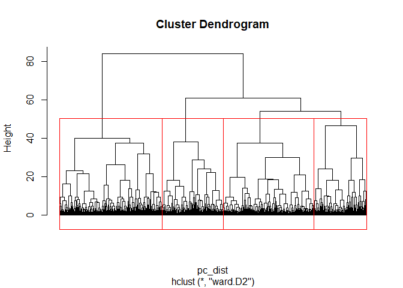

```r
pc_dist <- dist(IrlandaImput[,43:47])
hclust  <- hclust(pc_dist, method='ward.D2')
plot(hclust, hang=-1, labels=FALSE)

groups.k5 <- cutree(hclust, k = 4)
rect.hclust(hclust, k = 4, border="red")
```

[figure not shown]

```r
plot(silhouette(groups.k5, pc_dist))
```

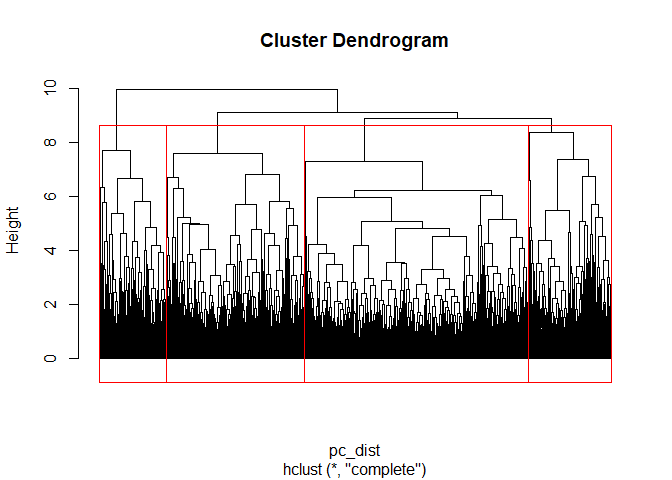

```r
pc_dist <- dist(IrlandaImput[,43:47])
hclust  <- hclust(pc_dist, method='complete')
plot(hclust, hang=-1, labels=FALSE)

groups.k5_c <- cutree(hclust, k=4)
rect.hclust(hclust, k=4, border="red")
```

[figure not shown]

```r
plot(silhouette(groups.k5_c, pc_dist))
```

```r
table(groups.k5,groups.k5_c)
```

```
##          groups.k5_c
## groups.k5   1   2   3   4
##         1 910 326 197 253
##         2 297  37 258 274
##         3 826 224 318 124
##         4 174  73  44 713
```

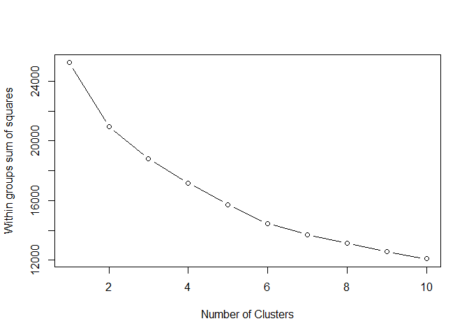

```r
# K-Means: number of clusters
wssplot <- function(xx, nc=15, seed=1234){
  wss <- (nrow(xx)-1)*sum(apply(xx,2,var))
  for (i in 2:nc){
    set.seed(seed)
    wss[i] <- sum(kmeans(xx, centers=i)$withinss)}
  plot(1:nc, wss, type="b", xlab="Number of Clusters",
       ylab="Within groups sum of squares")}
wssplot(IrlandaImput[,43:47], nc=10)
```

```r
#K-means cluster com K=4
kmeans.k6 <- kmeans(IrlandaImput[,43:47], 4, nstart=100)
IrlandaImput = IrlandaImput %>% mutate(cluster = kmeans.k6$cluster)
```

```r
table(groups.k5, IrlandaImput$cluster)
```

```
##
## groups.k5    1    2    3    4
##         1 1386   75  156   69
##         2    7  147  352  360
##         3   25 1210  171   86
##         4   82  187   37  698
```

```r
# O 2 e o 3 podem estar trocados
```

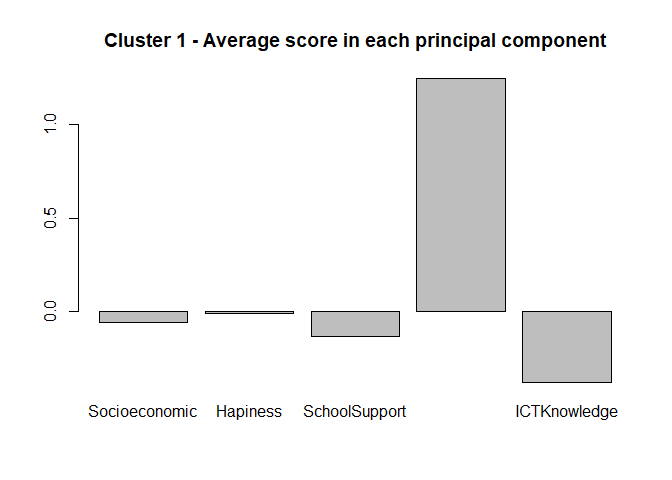

```r
#Barplot of average score in each principal component within each cluster
barplot(colMeans(subset(IrlandaImput,cluster==1)[,43:47]),main= "Cluster 1 - Average score in each principal component")
```

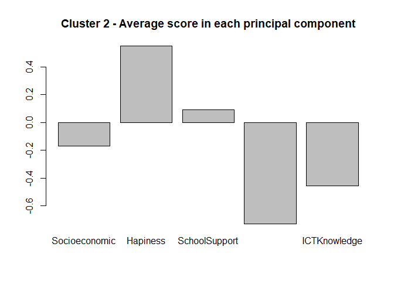

```r
barplot(colMeans(subset(IrlandaImput,cluster==2)[,43:47]),main= "Cluster 2 - Average score in each principal component")
```

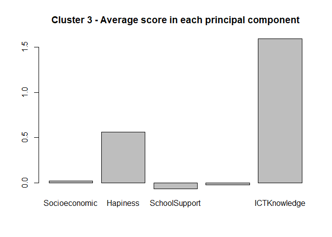

```r
barplot(colMeans(subset(IrlandaImput,cluster==3)[,43:47]),main= "Cluster 3 - Average score in each principal component")
```